# Confidence in Institutions, GSS 1973-2024

Fifty-one years of one question, and the summary that does not survive it

Democracy’s Data

Last updated September 13, 2026 at 10:53a EDT

Americans have lost faith in everything. You have read that sentence, or one of its cousins: trust has collapsed, institutions are in crisis, nobody believes in anything anymore. It is repeated so often that it reads as a fact rather than a claim. Is it true — did confidence fall in every institution, in which ones, and since when?

Answering needs something rare: the same question, asked the same way, for long enough to watch. Survey wording usually drifts, sponsors lose interest, and a question asked in 1975 is rarely asked in 2024 in a form anybody can compare. One battery of questions survived half a century intact, and most of what this brief can do rests on that fact.

## The test

The test is the [General Social Survey](https://gss.norc.org/), the GSS: a survey of American adults about their lives and opinions, run since 1972 by NORC, a survey research organization at the University of Chicago, and funded largely by the National Science Foundation, the federal agency that pays for basic research.[^1] Since 1973 its interviewers have read the same sentence to a national sample of American adults — a few thousand people chosen at random so that they stand in for the country — 33 times across 51 years:

> *“I am going to name some institutions in this country. As far as the people running these institutions are concerned, would you say you have a great deal of confidence, only some confidence, or hardly any confidence at all in them?”*

Nothing about the question is clever; its entire value is that nobody changed it. No election ever grades an answer like this — there is no true national figure for confidence, which is the standing condition of the Public Opinion cluster’s data chapter. When nothing outside the survey can grade the answer, the method is the whole credential, and this survey’s method held still. A survey whose product is the comparison across time has every incentive to leave its wording alone, and the GSS acted on that incentive for fifty years.

Two features of the wording should be fixed in mind before any number arrives. **It asks about “the people running” the institution**, not the institution itself, so somebody who reveres the Supreme Court and distrusts its current members is recorded as distrusting. And **there are only three options with no neutral middle**, so a lukewarm respondent has to choose “only some.” That is why the middle box is the largest almost everywhere, and why the interesting movement is at the two ends.

The battery also asks about 13 institutions in one interview, of the same respondents. That makes it an unusually fair test of the claim in the title: if confidence moved as a bloc, these 13 series should mostly move together.

## The data

The cumulative file — every year’s interviews stacked into one table, downloadable free from NORC at https://gss.norc.org/us/en/gss/get-the-data.html — is 570 megabytes in the format of Stata, a statistics program, holding 75,699 respondents and about six thousand variables, or columns. One row is one person interviewed, once, in one year. Here are the first five people interviewed in 1973, in six of those columns:

| year | id | conmedic | conlegis | conarmy | wtssps |
| --- | --- | --- | --- | --- | --- |
| 1973 | 1 | 2 | 2 | 1 | 0.7229722 |
| 1973 | 2 | 1 | 1 | 1 | 1.4825919 |
| 1973 | 3 | 2 | 2 | 2 | 0.7921651 |
| 1973 | 4 | 2 | 2 | 1 | 0.7814606 |
| 1973 | 5 | 2 | 2 | 2 | 0.7412959 |

The meaning lives in the codebook, not the file. `conlegis` is confidence in Congress, coded 1 for a great deal, 2 for only some, 3 for hardly any; `wtssps` is the survey weight the respondent carries. **A `2` is not a quantity.** It is the middle of three ordered boxes, so every number below is a share of people who picked a box, never an average of the codes. Alongside the three answers sit twelve distinct ways of not answering: don’t know, refused, inapplicable, skipped on web, and more. All twelve are treated below as the same thing: no answer.

Everything below rests on 427 rows like the one under this sentence, each of which reduces one year’s interviews about one institution to a single line. Here is what those 1,504 people become for Congress:

| Institution | Variable | Year | Answered | Great deal % | Only some % | Hardly any % |
| --- | --- | --- | --- | --- | --- | --- |
| Congress | conlegis | 1973 | 1458 | 24.1 | 60.6 | 15.2 |

One row per institution per survey year, in `confidence.csv`: the institution, its GSS `variable` name, the `year`, the number who `answered`, and the weighted shares `great_deal`, `only_some` and `hardly_any`, which sum to 100. A second table, `institutions.csv`, gives each institution its `first_year`, `last_year`, `survey_years` and the `change` across the series. What one row stands for has changed, from a person to an institution in a year, and there is no going back. Nothing below can ask whether the people who distrusted Congress also distrusted the press, because the rows that knew are gone.

Four decisions sit inside that one row. **The denominator is who answered, not who was asked.** The denominator is the bottom number, the figure the percentage is divided by: 1,458 of the 1,504 people interviewed in 1973 answered the Congress item, and the rest are simply not in the percentage. **Every percentage is weighted**, and weighting means counting some answers more than others, to make a sample that does not look like the country look like it; the targets are the Census Bureau’s figures for how many people of each age, sex, race and region the country holds. The weight used throughout is `wtssps`, the only one spanning every year in the file, so no seam between two weights lands inside the argument.

**An institution-year with fewer than fifty answers is dropped**, not shown small. And **twenty columns of six thousand were kept**: everything else about these respondents stays in the source file and cannot be recovered from these tables.

Two irregularities are the file’s own. The survey ran yearly into the 1990s and every other year after that, so the longest gap between readings is 3 years, across the pandemic. And one institution, banks and financial institutions, joined the battery in 1975, so its series is shorter than the rest.

> **Before you read on, commit to three answers.** Of the 13 institutions in the battery, how many fell between their first reading and their last — all 13? Ten? Seven? How many rose? And which single institution fell the furthest? Write the three down. A guess you have not written down is one you will quietly revise once you see the answer.

## What it says about democracy

Start with the series everybody quotes. Confidence in the people running Congress fell from 24.1% with a great deal of confidence in 1973 to 5.6% in 2024. The more striking number is at the other end: **“hardly any” went from 15.2% to 51.9%**, from about one respondent in seven to a clear majority.

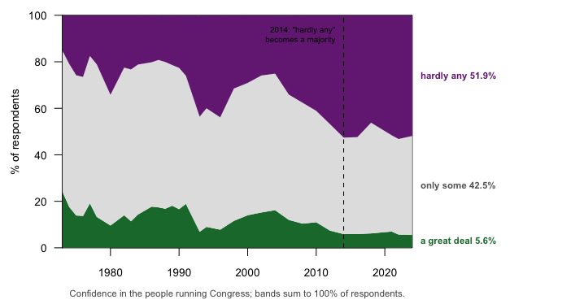

**Figure 1. Confidence in the people running Congress, drawn as a composition rather than a level.** The three answer shares at every survey year, stacked to 100% — the right form here, because every respondent picks exactly one of three boxes, so what moves is not a level but a mix. “Hardly any” overtook “a great deal” in 1974 and passed half of all respondents in 2014, marked by the dashed line. Even the lukewarm middle fell, from 60.6% to 42.5%.

At this point the summary is sitting there waiting to be written: *Americans have lost confidence in their institutions.* But the claim is about institutions in general, and only one has been looked at. The file holds 13 of them, asked of the same respondents. Here they are, ranked by how far each moved between its first reading and its last:

| Institution | First asked | Survey years | Change in % ‘great deal’ |
| --- | --- | --- | --- |
| Medicine | 1973 | 33 | -28.6 |
| Organized religion | 1973 | 33 | -20.2 |
| Congress | 1973 | 33 | -18.5 |
| Executive branch of federal government | 1973 | 33 | -17.5 |
| Education | 1973 | 33 | -17.4 |
| Banks and financial institutions | 1975 | 31 | -15.7 |
| Major companies | 1973 | 33 | -15.7 |
| Press | 1973 | 33 | -15.7 |
| U.S. Supreme Court | 1973 | 33 | -13.4 |
| Television | 1973 | 33 | -10.4 |
| Scientific community | 1973 | 33 | -4.8 |
| Organized labor | 1973 | 33 | 1.3 |
| Military | 1973 | 33 | 10.6 |

The largest decline is not a political institution at all. **Medicine is down 28.6 points**, further than Congress. Organized religion, the press, television, major companies, banks and education all fall by double digits. And the **military rose 10.6 points**, the only substantial increase anywhere in the file. Most readers name Congress for the steepest fall, and most put the number of risers at zero; neither holds.

A ranked list of thirteen differences invites a second mistake, which is reading the small ones as movements at all. Every number in that table is an estimate from a finite sample, and the difference between two estimates carries the uncertainty of both.

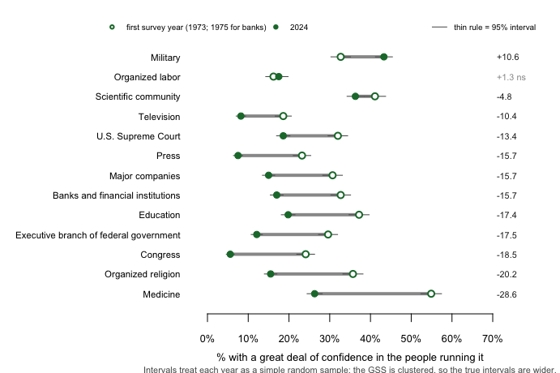

**Figure 2. First reading against last, with the uncertainty on each.** Share with a great deal of confidence in 1973 (hollow circle; 1975 for banks) against 2024 (filled), one row per institution, with a margin of error on each single reading — the thin rule, a range that would contain the true share nineteen times in twenty if the survey were repeated. Rows whose change does not clear the uncertainty of its two readings are drawn pale and marked *ns*, not significant. The intervals treat each year as a simple random sample, as if every respondent had been picked independently; in fact the GSS interviews people in clusters of neighbourhoods, so the true intervals are wider, which makes the small changes less secure rather than more.

Written out honestly: **eleven institutions fell, one rose, and one did not move.** Take organized labor, the row that did not move. In 1973, 16.2% had a great deal of confidence in the people running it; in 2024, 17.5%. The change is 1.3 points. But each of those readings came from a sample, and a different draw of people would have moved each one by a point or two: the first reading is good to about ±1.9 points and the second to about ±2.3. Put the two wobbles together and a difference of anything up to about 3.0 points could be nothing but the luck of who was asked. 1.3 is inside that, so the right description is *no detectable change*. That wobble is **sampling error**, the uncertainty that comes from asking a sample rather than everyone. Everything else moved by more than it can explain, including the scientific community’s 4.8-point fall, the smallest real decline in the set.

The exception deserves its story, because a single rise could be a fluke of the two endpoints Figure 2 happens to compare. Follow the military’s actual series:

| Year | Great deal (%) | Hardly any (%) |
| --- | --- | --- |
| 1973 | 32.7 | 17.2 |
| 1980 | 29.5 | 17.5 |
| 1986 | 32.3 | 13.3 |
| 1991 | 63.1 | 5.6 |
| 2000 | 42.0 | 9.7 |
| 2008 | 51.6 | 10.9 |
| 2018 | 62.2 | 6.8 |
| 2024 | 43.3 | 11.6 |

It is not a steady climb. It peaks at 63.1% in 1991, the year of the Gulf War, falls back, then rises again. That cuts directly against the long-slow-decline framing the Congress series invites: **confidence responds to events**, and it went up sharply when an institution did something visible and widely regarded at the time as successful. Whatever drives the other twelve series is capable of moving in both directions.

Where everything stands now completes the picture:

| Institution | Great deal (%) | Hardly any (%) | Net |
| --- | --- | --- | --- |
| Military | 43.3 | 11.6 | 31.7 |
| Scientific community | 36.3 | 12.0 | 24.3 |
| Medicine | 26.3 | 19.8 | 6.5 |
| Education | 19.8 | 25.8 | -6.0 |
| U.S. Supreme Court | 18.6 | 36.7 | -18.1 |
| Organized labor | 17.5 | 23.3 | -5.8 |
| Banks and financial institutions | 17.0 | 24.6 | -7.6 |
| Organized religion | 15.5 | 34.9 | -19.4 |
| Major companies | 15.0 | 24.3 | -9.3 |
| Executive branch of federal government | 12.1 | 46.4 | -34.3 |
| Television | 8.2 | 48.1 | -39.9 |
| Press | 7.5 | 55.0 | -47.5 |
| Congress | 5.6 | 51.9 | -46.3 |

Sorted by the net column, a pattern appears that the individual series conceal. The institutions people still trust do something technical and visible — the military, the scientific community, medicine. The ones at the bottom are the ones whose entire function is contestation: Congress, the press, television, the executive branch. Congress now stands at 5.6%, the lowest figure for anything asked about, and the Supreme Court at 18.6%.

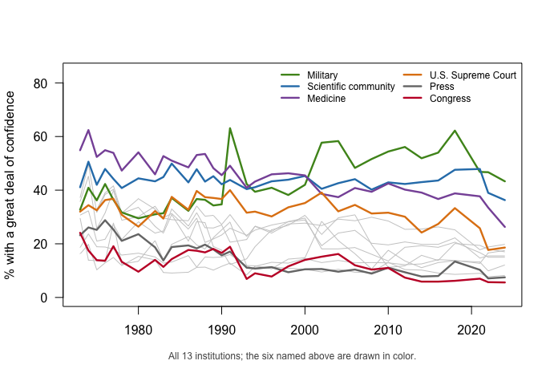

Move across for a year readout; hover a label to isolate a line, click to hide it.

So the sentence this brief opened with is not right as written. Something did happen to confidence in American institutions. But it is not uniform, it is not confined to government or even to politics, and at least one institution moved the other way. The largest loss belongs to medicine and the smallest to science, neither of which is a branch of government. That is a strange result for a story usually told about politics, and the unevenness is the finding.

## What this brief cannot tell you

Whether institutions became less trustworthy, or people became less trusting, or the phrase “a great deal of confidence” drifted in meaning across fifty years. The question records a report, not a relationship, and no amount of this series settles which changed. Citrin and Stoker add that trust measures move with partisanship:[^2] some of what looks like erosion about Congress is people disliking the party currently running it, and those people flip when control changes.

Whether the decline was warranted. The 1973 baseline sits immediately after Watergate and Vietnam, and institutions went on to earn skepticism through visible failures. Low confidence in a body whose approval rating has hovered around twenty percent for much of the past decade[^3] may be accurate perception rather than civic decay, and the data cannot tell those apart.

Whether Americans changed their minds, or the Americans who held the old view died and were replaced by people who never held it. The GSS is a cross-section — it samples new people each round; only a panel, a survey that goes back to the same people, could separate the two, and this design confuses them.

Who moved. The file built here carries no breakdowns by party, age, race or education, which is where most of the interesting variation in this literature lives. And the GSS changed how it collected answers in 2021, moving to web and mail during the pandemic.[^4] That is exactly the kind of break that can look like a trend, and it sits directly underneath every 2024 reading above.

## What you should have learned

- One unchanged question, asked 33 times across 51 years, is what makes the claim testable at all; almost no other social data holds still that long.
- The fall is real but wildly uneven: eleven of 13 institutions fell by more than sampling error can explain, one rose, and one did not move.
- The steepest loss is medicine’s 28.6 points, not Congress’s — the decline is not confined to government, or even to politics.
- The military’s series peaks at 63.1% in 1991 and rises overall, so whatever drives the declines is not an irreversible drift in national character.
- A percentage is a stack of decisions: who counts as answering, which weight, which cells are too thin to print. Every one of them was somebody’s choice.

## Extensions

- `institutions.csv` gives every institution a `change` across the series. Sort by it. Which institutions lost the most confidence, and which gained?
- `institutions.csv` also has `first_year`, `last_year` and `survey_years`. Find the institutions measured for fewer years than the rest. Does a shorter series make a bigger change easier to claim?
- `confidence.csv` keeps `great_deal`, `only_some` and `hardly_any` separately. Pick an institution whose `great_deal` fell. Did those people move to the middle, or all the way to the bottom?
- Find a year in `confidence.csv` where many institutions move together, using the `year` column. Then go and read what happened that year. Is the survey measuring the institutions, or the mood?
- **Stretch:** Gallup has asked its own confidence battery since 1973, with different wording and a fourth answer option. Pull its Congress series from https://news.gallup.com/poll/1597/confidence-institutions.aspx and set it beside this one. Where the two disagree, which difference — wording, options, sample — would you blame first?
- **Stretch:** the GSS Data Explorer at https://gssdataexplorer.norc.org/ can cross any confidence item by party identification. Pick one institution from Figure 3 and find out whether its decline belongs to one party or both.

## Sources

**Data**

- General Social Survey cumulative file, 1973–2024, collected by NORC at the University of Chicago and downloadable free at https://gss.norc.org/us/en/gss/get-the-data.html; the survey’s home page is https://gss.norc.org/. The two tables below reduce it to the 427 institution-years read here, weighted with `wtssps` throughout.
- NORC. *2021 GSS Methodological Primer* — the move to web and mail during the pandemic, which sits under every 2024 reading above. https://gss.norc.org/content/dam/gss/get-documentation/pdf/other/2021_GSS_Methodological_Primer.pdf

**Academic literature**

- Citrin, J. and Stoker, L. (2018). “Political Trust in a Cynical Age.” *Annual Review of Political Science* 21: 49–70, doi:10.1146/annurev-polisci-050316-092550.
- Gallup. *Congress and the Public* — the approval series the caveat above refers to. https://news.gallup.com/poll/1600/congress-public.aspx

**The data itself**

Every figure above is drawn from these tables. They are plain CSV, they open in a spreadsheet, and they are yours to take further.

`confidence.csv`, `institutions.csv`

[^1]: NORC’s own account of the survey: https://gss.norc.org/us/en/gss/about-the-gss.html.
[^2]: Jack Citrin and Laura Stoker, “Political Trust in a Cynical Age,” *Annual Review of Political Science* 21 (2018): 49–70, doi:10.1146/annurev-polisci-050316-092550.
[^3]: Gallup’s Congress approval series, which asks a different question — approval of the job Congress is doing — of a different sample: https://news.gallup.com/poll/1600/congress-public.aspx.
[^4]: NORC’s account of the change: *2021 GSS Methodological Primer*, https://gss.norc.org/content/dam/gss/get-documentation/pdf/other/2021_GSS_Methodological_Primer.pdf.